# Walaka Impacts on Reef Predators at a Remote Atoll

CG Meyer, et al. (in review); Code by C. Wall, R. Garcia-Seoane

2025-09-18

## Project Overview

Extreme storms can rapidly devastate coral reefs, yet their consequences for apex predators remain unclear. We combined year-long acoustic monitoring of 25 tagged predators (giant trevally *Caranx ignobilis*, Galapagos sharks *Carcharhinus galapagensis*, tiger sharks *Galeocerdo cuvier*) at French Frigate Shoals (Hawaiʻi) with bulk and compound-specific amino-acid stable isotope analyses of pre-storm muscle tissue to assess survival, space use, and trophic pathways surrounding Category-4 Hurricane Walaka (October 2018).

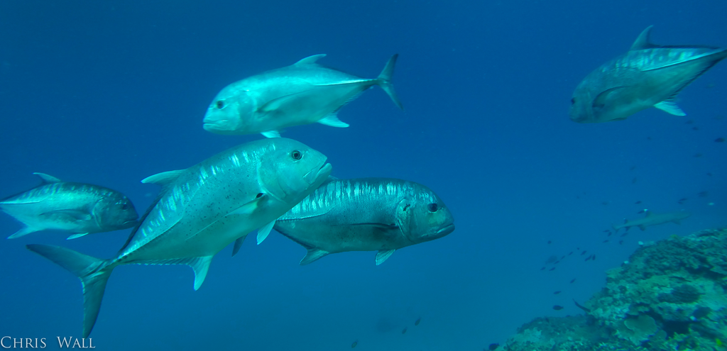

**Image**. Giant trevally (*Caranx ignobilis*) in the Northwestern Hawaiian Islands. *Photo credit*: C. Wall

### Data Description

Data here consists of bulk and amino acid δ<sup>13</sup>C and δ<sup>15</sup>N isotope values for Giant trevally (*Caranx ignobilis*) and Galapagos sharks (*Carcharhinus galapagensis*) from the Northwestern Hawaiian Islands, at French Frigate Shoals atoll (’ōlelo Hawai’i: *Lalo* or *Mokupāpapa*). We also include data used to calculate residence index using telemetry, as well as info on tagging dates and consumer fork length. Lastly, we incorporate the data from `Skinner et al. (2021)` reporting δ<sup>13</sup>C isotope values for essential amino acids (EAAs) collected inshore and offshore, using coral reef fishes and invertebrates (plankton and squid) in the Maldives. These are used as training data to assign fish consumers and determine the proportion support of food web support to consumers.

`Skinner, et al,. 2021. Offshore pelagic subsidies dominate carbon inputs to coral reef predators. Science advances 7.`

### Bulk tissue analysis

Use δ<sup>13</sup>C and δ<sup>15</sup>N biplots and perform `SIBER: Stable Isotope Bayesian Ellipse in R` analysis. This will plot the raw data with the standardized ellispe area, with 40% probability. This calculates the Isotope Niche Width

```r
### BULK d13C-d15N BIPLOT AND STANDARD ELLIPSES###

# load the SIBER package: library(SIBER)
# load the data: library(dplyr)

# load bulk data
All.data<-read.csv("data/Walak_Trevl_Gshark.csv")

# subset to be only bulk d13C and d15N
df.bulk<- All.data %>%
  select(Group, d13C_bulk, d15N_bulk)

df.bulk<-na.omit(df.bulk) # remove NAs

df.bulk$Group<-factor(df.bulk$Group, levels=c("GT", "GS")) # make factor level

# make levels for Siber
df.bulk$group<- ifelse(df.bulk$Group=="GT", "1", "2")
df.bulk$community<- ifelse(df.bulk$Group=="GT", "1", "2")

# rename d13C as "iso1", and d15N as "iso2", remove Group
df.Siber<- df.bulk %>%
  dplyr::rename(iso1 = d13C_bulk, iso2 = d15N_bulk) %>%
  select(-Group)

# create the siber object
siber <- createSiberObject(df.Siber)

# create lists of plotting arguments to be passed onwards to each of the three plotting functions
community.hulls.args <- list(col = 1, lty = 1, lwd = 1)
group.ellipses.args  <- list(n = 100, p.interval = 0.4,
                             lty = 2, lwd = 2)
group.hull.args      <- list(lty = 2, col = "grey20")

# ellipses and group.hulls are set to TRUE or T for short to force their plotting
palette(c("gold3", "chocolate4"))
par(mfrow=c(1,1))
plotSiberObject(siber,
                ax.pad = 2,
                hulls = F, community.hulls.args,
                ellipses = T, group.ellipses.args,
                group.hulls = F, group.hull.args,
                bty = "L",
                iso.order = c(1,2),
                xlab = expression({delta}^13*C~'‰'),
                ylab = expression({delta}^15*N~'‰'),
                x.limits=c(-17.7, -12.7),
                y.limits = c(9.1, 11.5)
)
```

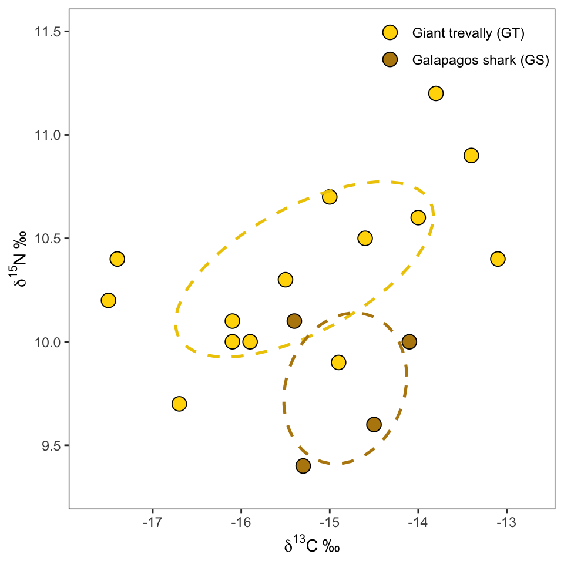

**Figure 4a.** Muscle tissue Isotopic biplot of from FFS predators. Isotopic biplot (δ<sup>13</sup>C vs. δ<sup>15</sup>N) of bulk muscle tissue from giant trevally and Galapagos sharks. Dashed ellipses represent 40% Bayesian ellipses.

```r
# go with ggplot, bc base R is BASSSSSIC
Siber.plot<-ggplot(data=df.bulk, aes(y=d15N_bulk, x=d13C_bulk))+
  geom_point(aes(fill=Group),  shape=21, size=4)+
  xlab(expression({delta}^13*C~'‰'))+
  ylab(expression({delta}^15*N~'‰'))+
  xlim(-17.7, -12.7)+
  ylim(9.3, 11.5)+
  theme_bw() + theme(panel.grid.major = element_blank(), panel.grid.minor = element_blank())+
  scale_fill_manual(values=c("gold", "darkgoldenrod"),
                    name = "",
                    labels = c("Giant trevally (GT)", "Galapagos shark (GS)"))+
  guides(fill = guide_legend(position="inside")) +
  theme(legend.background=element_blank()) +
  theme(legend.position.inside = c(0.81, 0.95)) +
# add in the ellipses from Siber
  stat_ellipse(aes(group = (Group),
                   color = Group),
               alpha = 0,
               level = 0.4,
               lty=2, size=0.9,
               type = "norm",
               geom = "polygon") +
  scale_color_manual(values=c("gold2", "darkgoldenrod")) +
  guides(color="none")

Siber.plot
```

Calculate the posterior estimates of the `Bayesian Standard Ellipse Area (SEA~B~)`. We will add this to the SIBER biplot generated above. The SEA<sub>B</sub> plot shows the 95%, 75%, and 50% credible intervals for each species, with modes indicated by black circles.

```r
# calculate summary statistics for each group: TA, SEA and SEAc
group.ML <- groupMetricsML(siber)
print(group.ML)

# use Bayesian Inference to calculate uncertainty around ellipses
# options for running jags
parms <- list()
parms$n.iter <- 2 * 10^4   # number of iterations to run the model for
parms$n.burnin <- 1 * 10^3 # discard the first set of values
parms$n.thin <- 10     # thin the posterior by this many
parms$n.chains <- 2        # run this many chains

# define the priors
priors <- list()
priors$R <- 1 * diag(2)
priors$k <- 2
priors$tau.mu <- 1.0E-3

# fit the ellipses which uses an Inverse Wishart prior on the covariance matrix Sigma, and a vague normal prior on the means
# fitting is via the JAGS method
ellipses.posterior <- siberMVN(siber, parms, priors)

# the posterior estimates of the ellipses for each group can be used to calculate the SEA.B for each group.
SEA.B <- siberEllipses(ellipses.posterior)
```

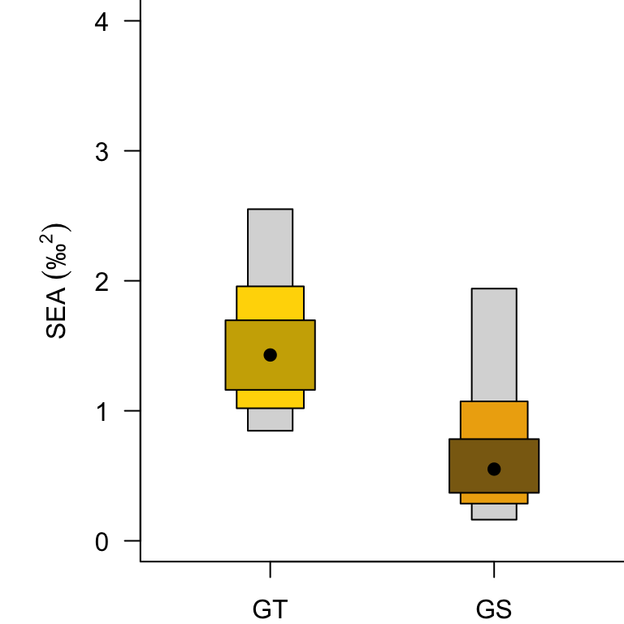

**Figure 4b.** Posterior estimates of the Bayesian Standard Ellipse Area (SEA<sub>B</sub>).

```r
# colors for SEAb plot
SEA.col<-matrix(c("gray85","gold", "gold3","gold","gray85",
                  "gray85", "darkgoldenrod2", "goldenrod4","darkgoldenrod2","gray85"), ncol=2, nrow=5)

par(mar=c(2,4.5,0,0))

### plot the SEAb figure
siberDensityPlot(SEA.B,
                 xticklabels= c("GT", "GS"),
                 xlab = "",
                 ylab = expression("SEA " ('‰' ^2) ),
                 bty = "L",
                 las = 1,
                 clr = SEA.col,
                 #main = "SIBER ellipses on each group",
                 ylim = c(0, 4))
```

```r
# will need this to export, but Rmd will run with the figure above
SEAb.plot<- recordPlot() # save SEAb plot in list
#plot.new() # close the "recording" of the plot -- really difficult to save this within R.
#SEAb.plot
```

```r
# add to other plot. Will require cleaning up in Affinity. SIBER isn't most user friendly.
  ggdraw() +
  draw_plot(Siber.plot) +
  draw_plot(SEAb.plot, .17, .712, .34, .22)
```

```r
dev.copy(pdf, "figures/Fig.4.Siber.pdf", height=8, width=8)
dev.off()
```

### δ<sup>15</sup>N Amino Acid Analysis

`Y. Chikaraishi, et al. Limnol Oceanogr Methods 7, 740–750 (2009)`. `M. Décima, et al. Limnol Oceanogr 62, 2308–2322 (2017)`.

#### Calculations

**Equation 1 and 2.** *Trophic position of fishes using AA-Glx and Phe, with calculations based on two approaches.
$${TP_{Glx-Phe}} = \frac{(δ^{15}N_{Glx}~ -
δ^{15}N_{Phe} - \beta)}{TDF} +1$$

- In this equation, *β* is the difference between δ<sub>15</sub>N values between Glx and Phe in marine primary producers, while TDF denotes the trophic discrimination factor, representing the <sub>15</sub>N enrichment between Glx and Phe per trophic level. `Here we adopt β = 3.4‰ and TDF = 7.6‰ for fishes`.
- We also report `TP~Glx-Phe~ using TDF = 5.9‰`, originally developed for sharks and rays.

**Equation 3.** *Trophic position of fishes using AA-Ala and Phe, with calculations following `Decima et al (2017)`.
$${TP_{Ala-Phe}} = \frac{(δ^{15}N_{Ala}~ -
δ^{15}N_{Phe} - \beta)}{TDF} +1$$

- Additionally, we calculated TP using δ<sub>15</sub>N values of Ala and Phe (TP<sub>Ala-Phe</sub>), which account for the contribution of protists, with `β = 3.2‰`, representing the δ<sub>15</sub>N difference between Ala and Phe in marine primary producers, and `TDF = 4.5‰`, representing the <sub>15</sub>N enrichment between Ala and Phe per trophic level.

**Equation 4.** *Protistan Trophic Steps.*
$$PTS = (δ^{15}N_{Ala-Phe}~ -
δ^{15}N_{Glx-Phe})$$

- Protistan trophic steps (i.e.,PTS) recorded in trevally and sharks was estimated using the difference between TP<sub>Ala-Phe</sub> and TP<sub>Glx-Phe</sub>.

**Equation 5.** *Average source amino acid δ<sub>15</sub>N.*
$$δ^{15}N_{SAA} =
mean(δ^{15}N_{Phe}~ + δ^{15}N_{Lys})$$

- To assess changes in nitrogen sources at the base of the food web, we calculated the average δ<sup>15</sup>N values of the source AAs, Phe and Lys, collectively referred to as δ<sup>15</sup>N<sub>SAA</sub>

```r
# info on calculations


### BOXPLOTS, ANOVA AND CORRELATIONS WITH RESIDENCY_INDEX###

# load ggplot2 package: library(ggplot2)
# load the data: library(dplyr)
AA.indic <- All.data %>%
  dplyr::select(Group, Residency.index, Residency, d15N_SAA, TPGlx_Phe, TPAla_Phe, PTS)

AA.indic<-na.omit(AA.indic)

AA.indic$Residency<-factor(AA.indic$Residency, levels=c("low", "high"))

AA.indic$Res.cat<-ifelse(AA.indic$Residency=="low", "< 0.1 offshore", ">= 0.1 inshore")
AA.indic$Res.cat<- factor(AA.indic$Res.cat, levels=c("< 0.1 offshore", ">= 0.1 inshore"))

AA.indic$Group<-factor(AA.indic$Group, levels=c("GT", "GS"))
```

#### Residency Histogram

Plot a histogram of residency. This will be used to motivate the binning as “inshore and offshore.”

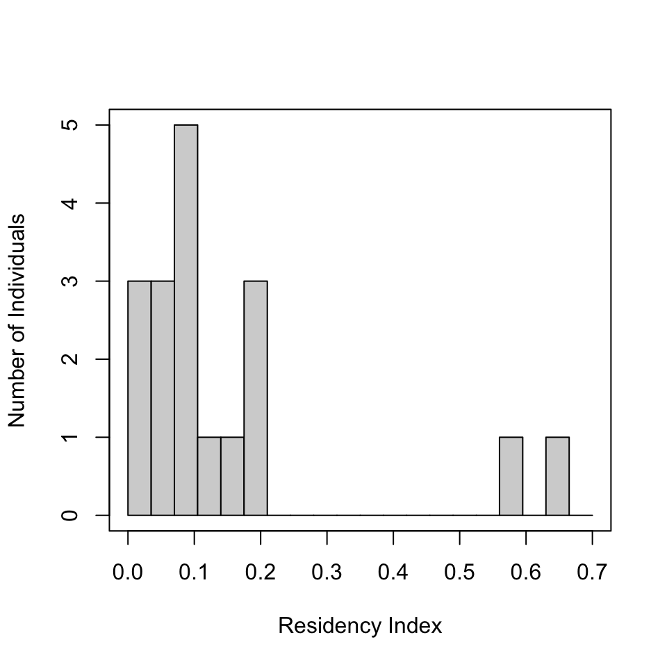

**Figure S2.** Histogram showing the frequency distribution of Residency Index values for giant trevally and Galapagos shark sampled for stable isotope analysis.

```r
hist(AA.indic$Residency.index, main="", ylab="Number of Individuals", xlab="Residency Index",
     breaks = seq(0,0.7, 0.035))
box(lty = 1, col = 'black')
```

```r
dev.print(pdf, "figures/Fig.S2.histogram.pdf", width=6, height=6)
dev.off()
```

Run for loops to create boxplots of δ<sup>15</sup>N amino acid metrics with fish residency. Here we use two categories for residency based on residency scores.

- **low inshore residency** = scores of < 0.1, classified as “offshore”.
- **high inshore residency** = scores >=0.1, classified as “inshore”

```r
#### #### #### #### #### #### ####
#### boxplots high residency
# (Residency_index ≥ 0.1, ∼inshore) vs low residency (Residency_index < 0.1, ∼offshore)
# list of variables to analyze
vars <- c("d15N_SAA", "TPGlx_Phe", "TPAla_Phe", "PTS") # we use these for boxplot and for regression
p.box<- list()

# data frame to store model results
results.box <- data.frame()

for (var in vars) {
  # fit linear model
model <- lm(AA.indic[[var]] ~ AA.indic$Res.cat)
summary_model <- summary(model)

# save results in the results data frame
results.box <- rbind(results.box, data.frame(
    Variable = var,
    Intercept = coef(model)[1],
    Slope = coef(model)[2],
    R2 = summary_model$r.squared,
    p_value = summary_model$coefficients[2,4]
  ))

# plot using ggplot2
  p.box[[var]] <- ggplot(AA.indic, aes(x = Res.cat, y = .data[[var]])) +
    geom_boxplot(aes(fill = Res.cat), alpha=0.8) +
    xlab("Residency")+
    scale_fill_manual(values=c("dodgerblue", "springgreen4"))+
    scale_y_continuous(labels = scales::number_format(accuracy = 0.1))+
    theme_bw() + theme(panel.grid.major = element_blank(), panel.grid.minor = element_blank()) +
    guides(fill="none")

  #print(p.reg)
  #ggsave(p.reg, file=paste0("figures/plot_", var,".pdf"), width = 5, height = 5, units = "in")
}

wrap_plots(p.box, ncol=1) # plot list with 'patchwork'
```

```r
#ggsave("figures/FigS3.boxplot.Lpanel.pdf", height=12, width=3.5) # save and export as a pdf
#dev.off()

# of thge above models, only these two are significant ANOVA
model.SAA <- aov(d15N_SAA ~ Residency, data = AA.indic)
anova(model.SAA) # signif p=0.016

model.TPgp <- aov(TPGlx_Phe ~ Residency, data = AA.indic)
anova(model.TPgp) # signif p=0.026
```

```r
# display results for boxplot tests
print(results.box) #
```

```
##               Variable Intercept   Slope         R2    p_value
## (Intercept)   d15N_SAA      2.47  1.0675 0.31101426 0.01618150
## (Intercept)1 TPGlx_Phe      3.30 -0.2500 0.27292576 0.02613531
## (Intercept)2 TPAla_Phe      5.14 -0.1400 0.03525180 0.45562996
## (Intercept)3       PTS      1.86  0.0900 0.02647059 0.51890557
```

Use linear regressions to test correlations between δ<sup>15</sup>N amino acid metrics and fish Residency Index.

```r
#######  Regression plots: correlations with Residency_index  #######
# set up for loop

# data frame to store results
results <- data.frame()

# linear regression and plotting for each variable
p.reg = list() # a list to save plots in

###### run the loop
for (var in vars) {
# fit linear model
model <- lm(AA.indic[[var]] ~ AA.indic$Residency.index)
summary_model <- summary(model)

# save results in the results data frame
results <- rbind(results, data.frame(
    Variable = var,
    Intercept = coef(model)[1],
    Slope = coef(model)[2],
    R2 = summary_model$r.squared,
    p_value = summary_model$coefficients[2,4]
  ))

# plot using ggplot2
  p.reg[[var]] <- ggplot(AA.indic, aes(x = Residency.index, y = .data[[var]])) +
    geom_point(aes(shape = Group), color="springgreen4", size = 2) +
    scale_shape_manual(values=c(19,17))+
    geom_smooth(method = "lm", se = TRUE, color = "springgreen4", fill = "springgreen4", alpha=0.2) +
    labs(x = "Residency index",
         y = var)+
    theme(aspect.ratio = 1) +
    scale_y_continuous(labels = scales::number_format(accuracy = 0.1))+
    theme_bw() + theme(panel.grid.major = element_blank(), panel.grid.minor = element_blank())

  #print(p.reg)
  #ggsave(p.reg, file=paste0("figures/plot_", var,".pdf"), width = 5, height = 5, units = "in")
}

# view and save plots
# wrap_plots(p.reg, ncol=1) # plot list with 'patchwork'

######## combine plots
box<-grid.arrange(grobs= p.box, ncol=1) # save as object that isn't a 'grob'
```

```r
reg<-grid.arrange(grobs= p.reg, ncol=1)
```

Results from linear regressions of δ<sup>15</sup>N amino acid metrics and Residency Index.

```r
# display results for regressions
print(results) # not significant for any, but nearly so for d15N-SAA (p=0.057)
```

```
##               Variable Intercept      Slope         R2    p_value
## (Intercept)   d15N_SAA  2.563021  2.5428245 0.20861710 0.05672148
## (Intercept)1 TPGlx_Phe  3.233997 -0.3007233 0.04668433 0.38917370
## (Intercept)2 TPAla_Phe  5.022106  0.3711458 0.02928781 0.49714886
## (Intercept)3       PTS  1.804644  0.6357061 0.15612195 0.10462122
```

Combine boxplots and regression plots for δ<sup>15</sup>N amino acid data with residency index to produce 8 panel figure. This is compiled **Figure S3**.

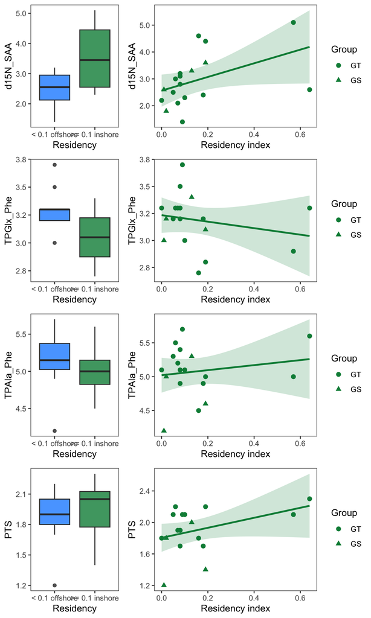

**Figure S3.** (*Left*) Boxplots showing differences in δ<sup>15</sup>N<sub>SAA</sub>, TP<sub>Glx-Phe</sub>, TP<sub>Ala-Phe</sub>, and PTS between fish with low residency index (< 0.1, greater offshore nutrient contribution) and a high residency index (≥ 0.1, greater inshore nutrient contribution). (*Right*) Panels show the relationships between predators (giant trevally [circles], Galapagos shark [triangles]) and δ<sup>15</sup>N<sub>SAA</sub>, TP<sub>Glx-Phe</sub>, TP<sub>Ala-Phe</sub>, and PTS.

```r
plot_grid(box, reg, ncol=2, rel_widths=c(0.5, 1)) # combine and set widths
```

```r
ggsave("figures/Fig.S3.box.regr.pdf", height=12, width=7) # save and export as a pdf
dev.off()
```

### δ<sup>13</sup>C Amino Acid Analysis

Here we use the δ<sup>13</sup>C values of essential amino acids to trace the determine the reliance of fishes on inshore vs. offshore production.

#### Linear Discriminant Analysis

Subset the data and use ‘sources’ to generate training data that will later be used to assign consumer. It is important that sources are distinct and have high accuracy in their assignment, otherwise they may not be informative as distinct energy channels/prey items.

Source groups consisted of coral reef consumers, including fishes, plankton, and squid, which reflect the primary producers of their respective habitats (benthic versus pelagic) and food webs (inshore versus offshore). Three source groups were used: “reef-associated plankton” represented by diurnal (*Caesio varilineata*, *Caesio xanthonota*) and nocturnal fishes (*Myripristis violacea*); “pelagic plankton” derived from squid (*Uroteuthis duvaucelii*); and “coral” derived from coralivorous fish (*Chaetodo meyeri*) found in `Skinner et al. (2021).`

```r
########## LDA setup

raw.df$SampleID<-as.factor(raw.df$SampleID)
raw.df$Group<-as.factor(raw.df$Group)

# remove all samples, keep source
prod <- raw.df[!(raw.df$Group == "GT" |raw.df$Group == "GS"),]
prod$Group<-droplevels(prod$Group) # drop sample levels

#Run an LDA with a jackknifing model fit to look at error rate
#'CV = TRUE' makes the LDA run a jackknifed - leave one out - model fit
All.lda <- lda(Group ~Thr + Val + Leu + Phe + Lys, data = prod, CV = TRUE)
```

Here, show LDA classification of sources performed with 100% success.

```r
#Create a table which compares the classification from the LDA model to the actual classification
All.reclass <- table(prod$Group, All.lda$class) #100% success

#Total percent of samples correctly classified is the sum of the diagonal of this table
sum.dig<-sum(diag(prop.table(All.reclass))) #100% !

accur<-mean(All.lda$class == prod$Group) # mean accuracy

#Percent of each producer Group correctly reclassified: 100% for all groups
reclass<-diag(prop.table(All.reclass, 1))

# print results
All.reclass
```

```
##
##                   Coral PelagicPlankton ReefPlankton
##   Coral               9               0            0
##   PelagicPlankton     0               8            0
##   ReefPlankton        0               0           25
```

Show the training data with the coefficients of linear discriminants and proportion of trace for LD1 and LD2. This shows the EAA that are driving patterns across the data visualization, as well as the % trace explained on each axis. Here 79% of variation is explained by PC1 and this is strongly affected by threonine (Thr) and phenylalanine (Phe).

```r
#Create a training LDA function from the library data
All.train <- lda(Group~ Thr + Val + Leu + Phe + Lys, data = prod)
All.train
```

```
## Call:
## lda(Group ~ Thr + Val + Leu + Phe + Lys, data = prod)
##
## Prior probabilities of groups:
##           Coral PelagicPlankton    ReefPlankton
##       0.2142857       0.1904762       0.5952381
##
## Group means:
##                        Thr       Val       Leu       Phe       Lys
## Coral            -8.378889 -21.12333 -19.74556 -15.02444 -12.83556
## PelagicPlankton  -8.485000 -22.72750 -23.35125 -24.77125 -16.25500
## ReefPlankton    -13.307200 -24.07960 -23.55920 -21.27280 -18.21480
##
## Coefficients of linear discriminants:
##              LD1         LD2
## Thr  1.226787772 -0.47940410
## Val -0.071830357  0.66667233
## Leu -0.269481800 -0.14587473
## Phe -1.480860015  0.09941465
## Lys  0.009195137 -1.08451168
##
## Proportion of trace:
##    LD1    LD2
## 0.7913 0.2087
```

```r
# save as txt file
sink("output/Walak_LDA_Train_Info.txt")
print(All.train)
sink()
```

Classify consumers (giant trevally or Galapagos shark) as belonging to the three source groups.

- *We show* the classification gives about 1/2 of the trevally as inshore vs. offshore, with 3 of 4 sharks being inshore.

```r
####### ######## ######## ######## #####
######## Classify Trevaly and Sharks ####
######## ######## ######## ######## #####

# remove all samples, keep source
cons.df <- raw.df[(raw.df$Group == "GT" |raw.df$Group == "GS"),]
cons.df$Group<-droplevels(cons.df$Group) # drop sample levels

cons.predict <- predict(object = All.train, newdata = cons.df)

cons.predict.data <- data.frame(SampleID = cons.df$SampleID, Group = cons.df$Group, LD.class = cons.predict$class, cons.predict$x)

All.reclass <- table(cons.df$Group, cons.predict$class)
All.reclass
```

```
##
##      Coral PelagicPlankton ReefPlankton
##   GS     0               1            3
##   GT     0               7            6
```

```r
#  GS: 1 as PelagicPlank, 3 as ReefPlankton
#  GT: 7 as PelagicPlank, 6 as ReefPlankton
```

Plot the LDA with producer groups and the consumers. **This is Figure 5**

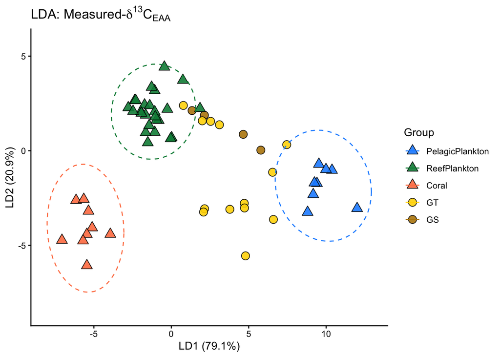

**Figure 5.** Linear discriminate analysis (LDA) of δ<sup>13</sup>C<sub>EAA</sub> fingerprints from reef-associated plankton, pelagic plankton and coral compared with those of predators. Ellipses denote 95% confidence intervals for each source group.

```r
#### plot it
raw.norm.LD.data$Group<-factor(raw.norm.LD.data$Group,
                      levels=c("PelagicPlankton", "ReefPlankton", "Coral",
                               "GT", "GS"))

lda.5.colors <- c("dodgerblue", "springgreen4","coral", "gold", "darkgoldenrod")


LDA.scat.Group <- ggplot(raw.norm.LD.data, aes(x = LD1, y = LD2))+
  geom_point(size = 3.5, color="black",
             aes(fill = Group, color = Group, shape = Group), alpha = 0.9) +
  stat_ellipse(type = "norm", level = 0.95, linewidth = 0.5, aes(lty = Group, color = Group))+
  scale_color_manual(values = lda.5.colors)+
  scale_fill_manual(values = lda.5.colors)+
  scale_shape_manual(values = c(24, 24, 24, 21, 21))+
  scale_linetype_manual(values = c(2,2,2,0,0))+
  xlab("LD1 (79.1%)") + ylab("LD2 (20.9%)") +
  ggtitle(expression(paste("LDA: Measured-", delta^{13}, C[EAA]))) +
  theme_classic() + guides(lty = "none")

LDA.scat.Group
```

```r
dev.copy(pdf, "figures/Fig.5.Walak_LDA_sorc_consumer.pdf", width=7, height=6)
dev.off()
```

### MixSIAR

LDA is great at classification, but cannot handle mixtures. Use a 3 member mixing model (reef plankton, pelagic plankton, coral) in MixSIAR to generate estimates of resource use. Once these models run, then perform *a posteriori* aggregation to generate estimates for 2 sources: inshore vs. offshore.

First, load in sources and generate the means and SD for each normalized-EAA.

```r
################################################
## MIXSIAR #####################################
################################################

# create a new data frame with desired columns for the consumers (mixtures)
Mix.df.EAA <- raw.norm.LD.data %>%
  dplyr::select("SampleID", "Group", "Thrn", "Valn", "Leun", "Phen", "Lysn")

# remove sources
Mix.df.EAA.consm <- Mix.df.EAA[!(Mix.df.EAA$Group == "ReefPlankton" | Mix.df.EAA$Group == "PelagicPlankton" |
                                  Mix.df.EAA$Group == "Coral"),]
Mix.df.EAA.consm$Group <- droplevels(Mix.df.EAA.consm$Group)
Mix.df.EAA.consm<-na.omit(Mix.df.EAA.consm)

# write and export a csv of the data frame
write.csv(Mix.df.EAA.consm, "output/EAAn_Mix/Walak_Mix.df.EAAn.consumer.csv", row.names = FALSE)

###########
# SOURCES #
###########

# NORMALIZED DATA
# Reef and pelagic plankton, coral

# create a new data frame with desired columns for the primary producers (sources)
Source.df.EAA <-  Mix.df.EAA[(Mix.df.EAA$Group == "ReefPlankton" | Mix.df.EAA$Group == "PelagicPlankton" |
                               Mix.df.EAA$Group == "Coral"),]

Source.df.EAA <- Source.df.EAA %>%
  dplyr::select("Group", "Thrn", "Valn", "Leun", "Phen", "Lysn")

##### source mean and SD
### Thr mean and SD
# calculate mean Thr values for the sources
mean.Thr.df.EAA <- aggregate(Thrn ~ Group, data = Source.df.EAA, FUN = mean)
colnames(mean.Thr.df.EAA) <- c("Group", "Mean.Thrn")

# calculate standard deviations of Thr values for the sources
sd.Thr.df.EAA <- aggregate(Thrn ~ Group, data = Source.df.EAA, FUN = sd)
colnames(sd.Thr.df.EAA) <- c("Group", "SD.Thrn")

### Val mean and SD
# calculate mean Val values for the sources
mean.Val.df.EAA <- aggregate(Valn ~ Group, data = Source.df.EAA, FUN = mean)
colnames(mean.Val.df.EAA) <- c("Group", "Mean.Valn")

# calculate standard deviations of Val values for the sources
sd.Val.df.EAA <- aggregate(Valn ~ Group, data = Source.df.EAA, FUN = sd)
colnames(sd.Val.df.EAA) <- c("Group", "SD.Valn")

### Leu mean and SD
# calculate mean Leu values for the sources
mean.Leu.df.EAA <- aggregate(Leun ~ Group, data = Source.df.EAA, FUN = mean)
colnames(mean.Leu.df.EAA) <- c("Group", "Mean.Leun")

# calculate standard deviations of Leu values for the sources
sd.Leu.df.EAA <- aggregate(Leun ~ Group, data = Source.df.EAA, FUN = sd)
colnames(sd.Leu.df.EAA) <- c("Group", "SD.Leun")

### Phe mean and SD
# calculate mean Phe values for the sources
mean.Phe.df.EAA <- aggregate(Phen ~ Group, data = Source.df.EAA, FUN = mean)
colnames(mean.Phe.df.EAA) <- c("Group", "Mean.Phen")

# calculate standard deviations of Phe values for the sources
sd.Phe.df.EAA <- aggregate(Phen ~ Group, data = Source.df.EAA, FUN = sd)
colnames(sd.Phe.df.EAA) <- c("Group", "SD.Phen")

### Lys mean and SD
# calculate mean Phe values for the sources
mean.Lys.df.EAA <- aggregate(Lysn ~ Group, data = Source.df.EAA, FUN = mean)
colnames(mean.Lys.df.EAA) <- c("Group", "Mean.Lysn")

# calculate standard deviations of Phe values for the sources
sd.Lys.df.EAA <- aggregate(Lysn ~ Group, data = Source.df.EAA, FUN = sd)
colnames(sd.Lys.df.EAA) <- c("Group", "SD.Lysn")

#### sample size
# calculate the number of samples for each of the sources
df.size.EAA <- aggregate(Lysn ~ Group, data = Source.df.EAA, FUN = length)
colnames(df.size.EAA) <- c("Group", "Lys.size")

# bind the values calculated above into one data frame
source.agg.df.EAA <- cbind(df.size.EAA,
                           mean.Thr.df.EAA[2], sd.Thr.df.EAA[2],
                           mean.Val.df.EAA[2], sd.Val.df.EAA[2],
                           mean.Leu.df.EAA[2], sd.Leu.df.EAA[2],
                           mean.Phe.df.EAA[2], sd.Phe.df.EAA[2],
                           mean.Lys.df.EAA[2], sd.Lys.df.EAA[2])
colnames(source.agg.df.EAA) <- c("", "n", "MeanThrn", "SDThrn", "MeanValn", "SDValn",
                                 "MeanLeun", "SDLeun", "MeanPhen", "SDPhen", "MeanLysn", "SDLysn")

# write and export a csv of the source data frame
write.csv(source.agg.df.EAA, "output/EAAn_Mix/Walak_source.agg.df.EAAn.csv", row.names = FALSE, na = "")
```

Now, load in the consumers. We use a TDF of 0 (with SD of 0) assuming direct routing of EAAs to consumers.

```r
# load consumer data and assign factors
# SampleID is a fixed factor
cons.EAAn <- load_mix_data(filename = "output/EAAn_Mix/Walak_Mix.df.EAAn.consumer.csv",
                          iso_names = c("Thrn", "Valn", "Leun", "Phen", "Lysn"),
                          factors = "SampleID",
                          fac_random = FALSE,
                          fac_nested = FALSE,
                          cont_effects = NULL)

# load source data
source.EAAn <- load_source_data(filename = "output/EAAn_Mix/Walak_source.agg.df.EAAn.csv",
                               source_factors = NULL,
                               conc_dep = FALSE,
                               data_type = "means",
                               cons.EAAn)

#Load TDF data
discr.EAAn <- load_discr_data(filename = "output/EAAn_Mix/MixSIAR_EAAn_TDFs.csv", cons.EAAn)
```

Set up here for the model (JAGs), run the model and save the output as an R.data file (can be memory intensive). For the sake of the Rmd-knitr, this is set to `eval=FALSE`.

```r
################## ################## #################
################## RUN MIXSIAR MODEL BY SAMPLEID #######

# define the model and error structure and write JAGS model file
# PROCESS ERROR ONLY - HAVE TO DO THIS WHEN RUNNING MIXTURE POINTS INDIVIDUALLY

model_filename.EAA <- "output/MixSIAR_models/EAAn_SampleID_model/MixSIAR_Model_SampleID_fixed.txt"
resid_err <- FALSE
process_err <- TRUE
write_JAGS_model(model_filename.EAA, resid_err, process_err, cons.EAAn, source.EAAn)

################################################
############# run the JAGS model

set.seed(12)
consm.jags.mod.EAAn <- run_model(run = "normal", cons.EAAn, source.EAAn, discr.EAAn, model_filename.EAA, alpha.prior = 1, resid_err, process_err)

#save RDS object of JAGS model
saveRDS(consm.jags.mod.EAAn, file = "output/MixSIAR_models/EAAn_SampleID_model/MixSIAR_Model_SampleID_rjags_norm.rds")
```

```r
# code below will read back in the RDS object
consm.jags.mod.EAAn <- readRDS(file = "output/MixSIAR_models/EAAn_SampleID_model/MixSIAR_Model_SampleID_rjags_norm.rds")
```

Generate plots for MixSIAR diagnostics. See the `MixSIAR model statistics` here. Gelman-Rubin values are < 1.05, and 2 of 3 chains in Geweke diagnostic perform well at <5% z-score.

```r
# note the processing here opens files in quartz and results in an issue with knitting. This is why code chunk is set to "eval = FALSE". Code runs otherwise.

# process diagnostics, summary stats, and posterior plots
output_options_EAAn <- list(
  summary_save = TRUE,
  summary_name = "output/MixSIAR_models/EAAn_SampleID_model/MixSIAR_SampleID_summary_stats.EAAn",
  sup_post = FALSE,
  plot_post_save_pdf = FALSE,
  plot_post_name = "output/MixSIAR_models/EAAn_SampleID_model/MixSIAR_SampleID_posterior_density.EAAn",
  sup_pairs = TRUE,
  plot_pairs_save_pdf = FALSE,
  plot_pairs_name = "output/MixSIAR_models/EAAn_SampleID_model/MixSIAR_SampleID_pairs_plot.EAAn",
  sup_xy = FALSE,
  plot_xy_save_pdf = TRUE,
  plot_xy_name = "output/MixSIAR_models/EAAn_SampleID_model/MixSIAR_SampleID_xy_plot.EAAn",
  gelman = TRUE,
  heidel = FALSE,
  geweke = TRUE,
  diag_save = TRUE,
  diag_name = "output/MixSIAR_models/EAAn_SampleID_model/MixSIAR_SampleID_diagnostics.EAAn",
  indiv_effect = FALSE,
  plot_post_save_png = FALSE,
  plot_pairs_save_png = FALSE,
  plot_xy_save_png = FALSE,
  graphics.off())
```

```r
output_diagnostics(consm.jags.mod.EAAn, cons.EAAn, source.EAAn, output_options_EAAn)
```

```
##
## ################################################################################
## # Gelman-Rubin Diagnostic
## ################################################################################
##
## Generally the Gelman diagnostic should be < 1.05
##
## Out of 106 variables: 10 > 1.01
##                       0 > 1.05
##                       0 > 1.1
##
## The worst variables are:
##              Point est. Upper C.I.
## p.fac1[17,1]   1.016869   1.035497
## p.fac1[9,1]    1.015209   1.039946
## p.fac1[7,1]    1.014457   1.032430
## loglik[9]      1.014359   1.024013
## loglik[16]     1.012579   1.022181
## p.fac1[16,1]   1.012560   1.027758
## p.fac1[1,1]    1.011651   1.037135
## p.global[1]    1.011651   1.037135
## p.fac1[12,3]   1.010392   1.039600
## p.fac1[4,1]    1.010207   1.030760
##
## ################################################################################
## # Geweke Diagnostic
## ################################################################################
##
## The Geweke diagnostic is a standard z-score, so we'd expect 5% to be outside +/-1.96
## Number of variables outside +/-1.96 in each chain (out of 106):
##
##        Chain 1 Chain 2 Chain 3
## Geweke      23       3       1
```

Output for figures causes quartz device to open, which also gives issue with knit in generating the html output. For the sake of the Rmd-knitr, this is set to `eval=FALSE`.

```r
# set max to get all data
options(max.print = 3000)
out.JAGS <- output_JAGS(consm.jags.mod.EAAn, cons.EAAn, source.EAAn, output_options_EAAn)

# get the output stats for the model
# output_stats(consm.jags.mod.EAAn, cons.EAAn, source.EAAn, output_options_EAAn)
```

Perform source aggregation to “inshore vs. offshore”.

```r
######### a posteriori aggregation of sources
# combine benthic algae and POM into one autochthonous source
consm.in.out.combined.EAAn <- combine_sources(consm.jags.mod.EAAn, cons.EAAn, source.EAAn, alpha.prior = 1,
                                          groups = list(Inshore = c("ReefPlankton", "Coral"),
                                                        Offshore = "PelagicPlankton"))

# print and save the interval plot
plot_intervals(consm.in.out.combined.EAAn, toplot = "fac1")
dev.copy(pdf, "output/MixSIAR_models/EAAn_SampleID_model/combines_output_intervals.EAAn.pdf", width=10, height=10)
dev.off()

#### # summary statistics for a posteriori aggregation of sources (inshore vs offshore)
# ***** NOTE ***** you will need to create a blank txt file if you run and re-run the aggregation. The file is not overwritten when you re-save in summary_stat(...). It will add outputs sequentially, which will make life terrible and code not-reproducible.

# make blank txt if re-running summary_stat(...)
file.create("output/MixSIAR_models/EAAn_SampleID_model/MixSIAR_SampleID_summary_stats_a_posteriori.EAAn.txt")

# run summary_stat and save output
summary_stat(consm.in.out.combined.EAAn, toprint = "fac1", meanSD = TRUE, savetxt = TRUE,
             quantiles = c(0.025, 0.05, 0.25, 0.5, 0.75, 0.95, 0.975),
             filename = "output/MixSIAR_models/EAAn_SampleID_model/MixSIAR_SampleID_summary_stats_a_posteriori.EAAn")
```

```r
################################################
### CLEAN MIXSIAR MODEL BY SAMPLEID RESULTS ###
################################################

SAMP.mixSIAR.EAAn.output.3 <- read.table(
  "output/MixSIAR_models/EAAn_SampleID_model/MixSIAR_SampleID_summary_stats.EAAn.txt",
  sep = '\t', header = FALSE, skip = 6)

SAMP.mixSIAR.EAAn.output.3 <- as.data.frame(SAMP.mixSIAR.EAAn.output.3)
colnames(SAMP.mixSIAR.EAAn.output.3) <- "full.data"

# remove all extra spaces using "squish", make them 1 space only
library(stringr)
SAMP.mixSIAR.EAAn.output.3$full.data <- str_squish(SAMP.mixSIAR.EAAn.output.3$full.data)

# rename columns
library(plyr)
samp.mix.EAAn.out.3 <- separate(SAMP.mixSIAR.EAAn.output.3, full.data,
                               into = c("factor", "Mean", "SD", "2.5.perc", "5.perc", "25.perc", "50.perc",
                                        "75.perc", "95.perc", "97.5.perc"), sep=" ")

# parse the factors here into 3 columns
new.cols.EAAn.3 <- stringr::str_split_fixed(samp.mix.EAAn.out.3$factor, "\\.", 3) %>%
  as.data.frame() %>%
  setNames(c("proportion", "SampleID", "Source"))

new.cols.EAAn.3 <- new.cols.EAAn.3 %>%
  dplyr::select("SampleID", "Source")

# combine the new, separated columns with the data, verify the levels match, then remove "factor"
Samp.out.cleaned.EAAn.3 <- cbind(new.cols.EAAn.3, samp.mix.EAAn.out.3[1:10])
Samp.out.cleaned.EAAn.3 <- Samp.out.cleaned.EAAn.3 %>%
  dplyr::select(-factor)

Samp.out.cleaned.EAAn.3<-Samp.out.cleaned.EAAn.3[-1,]

write.csv(Samp.out.cleaned.EAAn.3, "output/EAAn_Mix/Walak_MixSIAR_SampleID.df.EAAn.3sources.csv", row.names = FALSE)
```

#### 3 source MixSIAR plot

Plot of three sources and their contribution to consumers. **This is Figure 6a**

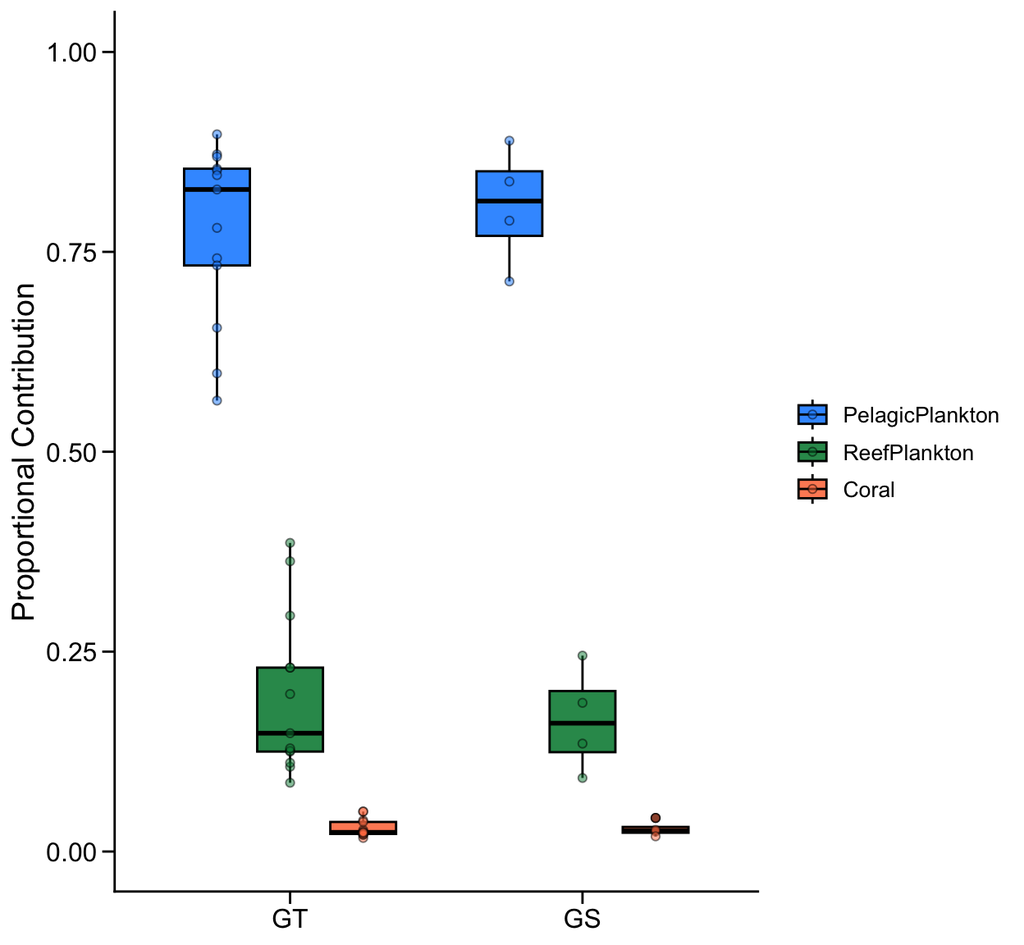

**Figure 6a.** Results of the MixSIAR Bayesian mixing model using δ<sup>13</sup>C<sub>EAA</sub> fingerprints. Proportional contribution of pelagic plankton, reef-associated plankton and corals to Giant trevally and Galapagos sharks.

```r
################## ready to plot ##################

# bring in some metadata to make sense of it
Mix.samp.EAAn.3 <- merge.data.frame(raw.norm.LD.data, Samp.out.cleaned.EAAn.3, by="SampleID")
Mix.samp.EAAn.3$Source <- factor(Mix.samp.EAAn.3$Source,
                                 levels = c("PelagicPlankton", "ReefPlankton", "Coral"))
Mix.samp.EAAn.3$Mean<-as.numeric(Mix.samp.EAAn.3$Mean)

# plot it: some general formatting here for the plot...
Fig.formatting <-
  theme(axis.ticks.length = unit(0.2, "cm"),
        axis.text.x = element_text(size = 12, color = "black"),
        axis.text.y = element_text(size = 12, color = "black"),
        axis.title.x = element_text(size = 14, color = "black"),
        axis.title.y = element_text(size = 14, color = "black"),
        legend.text = element_text(size = 10, color = "black"),
        legend.title = element_blank(),
        axis.ticks = element_line(color = "black"),
        legend.key.size = unit(0.6, "cm"))


## plot the 3 sources and consumers
Mix.samp.plot.EAAn.3 <- ggplot(data = Mix.samp.EAAn.3, aes(x = Group, y = Mean, fill = Source)) +
  geom_boxplot(alpha = 0.9, color = "black")+
  geom_point(aes(fill = Source), pch = 21, alpha = 0.5, color = "black",
             position = position_dodge(0.75))+
  scale_fill_manual(values = c("dodgerblue", "springgreen4","coral")) +
  ylab("Proportional Contribution") +
  xlab(NULL) +
  ylim(0,1) +
  guides(fill = guide_legend(title = expression(paste(AA[ESS], " ", Source)))) +
  theme_classic() + Fig.formatting + guides(color = "none")

#print and save
Mix.samp.plot.EAAn.3
```

```r
dev.copy(pdf, "figures/Fig.6A.Walak_Fig.mixsiar.3sour.EAAn.pdf", width = 7, height = 5)
dev.off()
```

#### 2 member MixSIAR plot

Using aggregated sources, plot the % contribution of inshore vs. offshore food web support to consumers

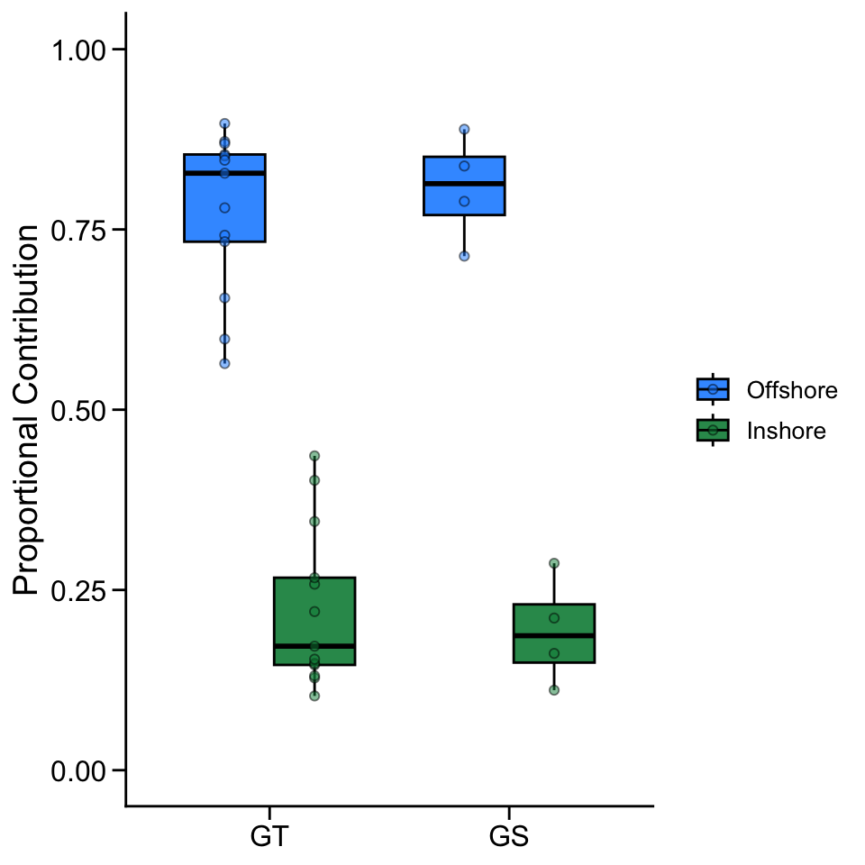

```r
samp.mix.df<-Samp.out.cleaned.EAAn
samp.mix.reduced <- samp.mix.df %>%
  dplyr::select(SampleID, Source, Mean, SD)

################# ################### ################ ################

# bring in some metadata to make sense of it
Mix.samp.EAAn.2 <- merge.data.frame(raw.norm.LD.data, samp.mix.reduced, by="SampleID")
Mix.samp.EAAn.2$Source <- factor(Mix.samp.EAAn.2$Source,
                                 levels = c("Offshore", "Inshore"))
Mix.samp.EAAn.2$Mean<-as.numeric(Mix.samp.EAAn.2$Mean)

write.csv(Mix.samp.EAAn.2, "output/Walak_Mix.samp.EAAn.2sources.csv")

########### plot
Mix.samp.plot.EAAn.InOff <- ggplot(data = Mix.samp.EAAn.2, aes(x = Group, y = Mean, fill = Source)) +
  geom_boxplot(alpha = 0.9, color = "black")+
  geom_point(aes(fill = Source), pch = 21, alpha = 0.5, color = "black", position = position_dodge(0.75))+
  scale_fill_manual(values = c("dodgerblue","springgreen4")) +
  ylab("Proportional Contribution") +
  xlab(NULL) +
  ylim(0,1) +
  guides(fill = guide_legend(title = expression(paste(AA[ESS], " ", Source)))) +
  theme_classic() + Fig.formatting + guides(color = "none")

#print and save grouped with 2 categories
Mix.samp.plot.EAAn.InOff
```

```r
dev.copy(pdf, "figures/Fig.NA.Walak_Fig.mixsiar.2sour.EAAn.pdf", width = 4, height = 5)
dev.off()
```

### Residency index

Here we use the residency index, or the events where the consumers were recorded by receiver arrays at French Frigate Shoals relative to the days the receivers were recording, to compare the proportion of inshore food web support to consumers.

We show that there is a significant correlation between the residency index and the % inshore food web use, dominated by the Giant trevlly, which are best represented in our dataset. The relationship is significant R<sub>2</sub> = 0.55 and *p*<0.001.

```r
Inshore.df<-Mix.samp.EAAn.2[(Mix.samp.EAAn.2$Source=="Inshore"),]
# write.csv(Inshore.df, "output/Inshore.df.csv")

# group mean model
Inshore.mod<-lm(Mean~Group, data=Inshore.df) #p=0.610, no difference in % inshore by group
Group.model<-anova(Inshore.mod)

# residency by mean model
Res.Inshore.mod<-lm(Mean~Residency.index, data=Inshore.df)
Res.sum<-summary(Res.Inshore.mod) #R2-adj = 0.55,  #p<0.001
anova(Res.Inshore.mod)
```

```
## Analysis of Variance Table
##
## Response: Mean
##                 Df   Sum Sq Mean Sq F value    Pr(>F)
## Residency.index  1 0.096760 0.09676  20.943 0.0003636 ***
## Residuals       15 0.069302 0.00462
## ---
## Signif. codes:  0 '***' 0.001 '**' 0.01 '*' 0.05 '.' 0.1 ' ' 1
```

This relationship is unchanged by the presence or absence of sharks in the data. Here, just giant trevally are used in the model, Adj-R<sub>2</sub> = 0.56 and *p*=0.002.

```r
# residency model if GS removed
Res.Inshore.mod.GT<-lm(Mean~Residency.index, data=Inshore.df[(Inshore.df$Group=="GT"),])
Res.sum<-summary(Res.Inshore.mod.GT) #R2-adj = 0.56, p=0.002
anova(Res.Inshore.mod.GT)
```

```
## Analysis of Variance Table
##
## Response: Mean
##                 Df  Sum Sq  Mean Sq F value  Pr(>F)
## Residency.index  1 0.08742 0.087420  16.343 0.00194 **
## Residuals       11 0.05884 0.005349
## ---
## Signif. codes:  0 '***' 0.001 '**' 0.01 '*' 0.05 '.' 0.1 ' ' 1
```

#### Residency by proportion of inshore foodweb support

Plot the relationship for residency index for all sames (sharks and trevally). **This is Figure 6b**

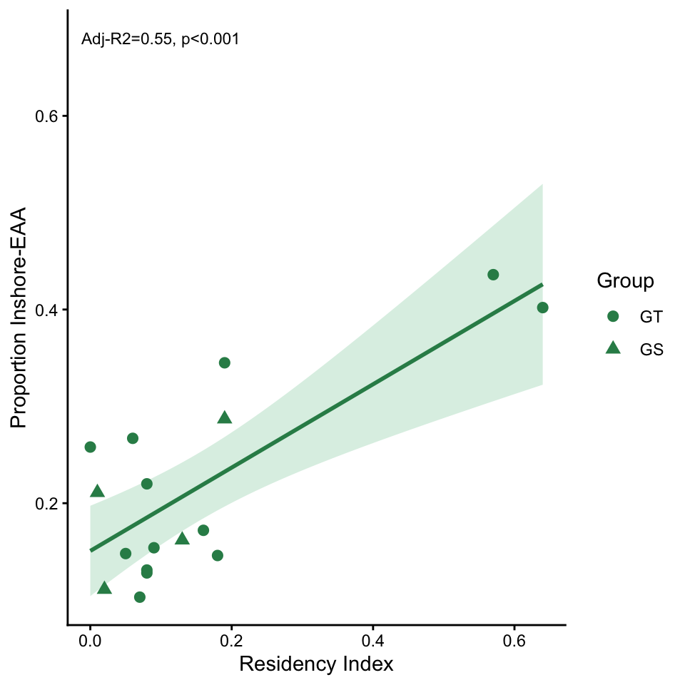

**Figure 6B.** Relationship between the proportion of inshore carbon sources utilized versus and the predator residency index. The correlation is significant (ANOVA, f = 20.943, p <0.001)

```r
Inshore.prop.plant<-ggplot(Inshore.df, aes(x=Residency.index, y=Mean)) +
  geom_smooth(method = lm, color="seagreen", alpha=0.2, fill="mediumseagreen")+
  geom_point(color="seagreen", size=2.5, aes(shape=Group))+
  ylab("Proportion Inshore-EAA")+
  xlab("Residency Index")+
  annotate("text", x = 0.10, y = 0.68, label = "Adj-R2=0.55, p<0.001", size = 3) +
  theme_classic()

Inshore.prop.plant
```

```r
ggsave("figures/Fig.6B.Walak_Inshore.prop.EAAn.pdf", width=5, height=5)
```